# 第一次作业（共 6 题）

## 第 1 题

输入两个点的坐标 $(x_1, y_1)$ 和 $(x_2, y_2)$，输出两点间距离是多少？结果保留2位小数

```python
import math

x1, y1 = 3, 0
x2, y2 = 0, 4

# 使用 math.hypot() 函数计算两点间距离，更加简洁
dist = math.hypot(x2 - x1, y2 - y1)
print(f"两点间距离为 {dist:.2f}")
```

```
两点间距离为 5.00
```

## 第 2 题

小明参加语文，数学和英语考试，输入小明的 3 门成绩，求 3 门成绩的和、平均以及最高和最低分是多少？ 如果三门课程以权重 0.5、0.3 和 0.2 计入总分，求小明的最终总评成绩是多少？

### 第 2 题输入

```
>> 输入语文成绩：80
>> 输入数学成绩：95
>> 输入英语成绩：88
```

### 第 2 题输出

```
>> Sum score 263
>> Average score 87.67
>> Highest score 95
>> Lowest score 80
>> Total 86.10
```

```python
from numpy import average

# DRY: Don't Repeat Yourself
scores = [int(input(f"输入{subject}成绩：")) for subject in ("语文", "数学", "英语")]

# 调包解决战斗！
print(f"Sum score {sum(scores)}")
print(f"Average score {average(scores):.2f}")
print(f"Highest score {max(scores)}")
print(f"Lowest score {min(scores)}")
print(f"Total {average(scores, weights=[0.5, 0.3, 0.2]):.2f}")
```

```
Sum score 263
Average score 87.67
Highest score 95
Lowest score 80
Total 86.10
```

## 第3题

在 $1 \sim 100$ 之间（包含 $1$ 和 $100$）产生三个随机整数 $a, b, c$。 求 $a, b, c$ 的最大公约数和最小公倍数。

```python
def gcd(a: int, b: int, *args: tuple[int]) -> int:
    """最大公约数：辗转相除法"""
    if args:
        return gcd(gcd(a, b), *args)
    return a if b == 0 else gcd(b, a % b)


def lcm(a: int, b: int, *args: tuple[int]) -> int:
    """最小公倍数：利用最大公约数"""
    if args:
        return lcm(lcm(a, b), *args)
    return a * b // gcd(a, b)
```

```python
import random

# The answer of the universe!
random.seed(42)

a, b, c = [random.randint(1, 100) for _ in range(3)]

print(f"{a = }, {b = }, {c = }")
print(f"{gcd(a, b, c) = }")
print(f"{lcm(a, b, c) = }")
```

```
a = 82, b = 15, c = 4
gcd(a, b, c) = 1
lcm(a, b, c) = 2460
```

## 第4题

创建长度为 $20$ 的列表，其元素为 $1000 \sim 5000$ 以内的随机数。 编写程序找出列表中**不能**被 $10$ 以内**素数**整除的元素。

```python
import random

random.seed(42)
primes_in_10 = (2, 3, 5, 7)

lst = [random.randint(1000, 5000) for _ in range(20)]
print(f"原始列表：{lst}")
print(
    f"不能被十以内素数整除的元素：{[x for x in lst if all(x % p != 0 for p in primes_in_10)]}"
)
```

```
原始列表：[3619, 1456, 1102, 4037, 2126, 2003, 1914, 1571, 4016, 1419, 3771, 4033, 4654, 3233, 1356, 3418, 2728, 1130, 1122, 1383]
不能被十以内素数整除的元素：[4037, 2003, 1571, 4033, 3233]
```

## 第5题

给定任意正整数 `n_row`，生成对应大小的三角形，然后使用 `print` 函数，绘制出将该三角形逐渐变为菱形的动画。**每 0.5 秒绘制一帧。**

- 如下图所示，对应 `n_row = 4` 的情形，即三角形的高位于第 4 行，然后第 1 行有 $1 + 2 \times 0$ 个星，第 2 行有 $1 + 2 \times 1$ 个星，第3行有 $1 + 2 \times 2$ 个星，第 4 行有 $1 + 2 \times 3$ 个星，第 5 行有 $1 + 2 \times 2$ 个星，第6行有 $1 + 2 \times 1$ 个星，第 7 行有 $1 + 2 \times 0$ 个星。
- 更一般的，正整数 `n_row` 生成的三角形，第 1 行有 1 个星，之后每行递增 2 个星，直至三角形高所在的第 `n_row` 行；然后每行递减 2 个星，直至有 1 个星的最后一行。

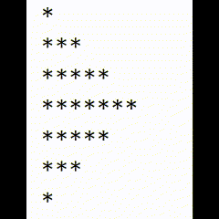

下面的代码给出了必要提示，请运行代码并观察输出。

```python
import time
from IPython.display import clear_output
```

```python
for i in range(2):
    for m in range(2):
        stars = "*" * (2 * m + 1)
        if m == 0:
            stars = " " * i + stars
        print(stars)
    time.sleep(1)
    clear_output(wait=True)
```

下面的格子已经定义好了`n_row`变量，请不要删除。记得尝试不同的`n_row`的取值，看看程序是否都能跑通。

```python
n_row = 10
```

请将你的代码写在后续的格子里。

```python
from time import sleep
from IPython.display import clear_output
```

```python
def draw_rhombus(n, space_limit=0):
    for i in range(n):
        blank = min(space_limit, n - i - 1)
        space_limit -= blank
        print(" " * blank + "*" * (2 * i + 1))
    for i in range(n - 1, -1, -1):
        blank = min(space_limit, n - i)
        space_limit -= blank
        print(" " * blank + "*" * (2 * i - 1))


def draw_animation(n):
    for i in range(n * (n - 1) + 1):
        draw_rhombus(n, i)
        sleep(0.5)
        clear_output(wait=True)
```

```python
draw_animation(n_row)
```

## **第6题**

蒙特卡洛模拟是一种利用随机数进行模拟的方法，可用于估算圆周率 $\pi$ 。其基本思想如下：

- 考虑下图，一个半径为 $r$ 的圆内切于一个边长为 $2r$ 的正方形。记圆的面积与正方形的面积的比值为 $S$，则根据圆面积公式与正方形面积公式，我们有 $$ S = \frac{\pi r^2}{ 2r \times 2r } = \frac{\pi}{4} $$
- 因此我们有 $$ \pi = 4 S $$
- 那么，怎么估算圆面积与正方形面积的比值 $S$ 呢？
  - 将一个半径为1的单位圆的圆心置于原点 $(0,0)$ 处。
  - 按均匀分布，在坐标范围 $[−1, 1] \times [−1, 1]$ 内随机采样 $N$ 个坐标点。
  - 计算每个采样点 $(x,y)$ 到原点 $(0,0)$ 的距离。如果满足 $x^{2}+y^{2} \leqslant 1$，则该点落入单位圆内，因此圆内点数加一。
  - 通过计算落入单位圆的点数占总点数的比例，即可得到对于 $S$ 的估算值，进而估算 $\pi$ 为： $$ \pi \approx 4 \times \frac{\text{圆内点数}}{\text{总点数}} = 4\times \frac{\text{圆内点数}}{N} $$

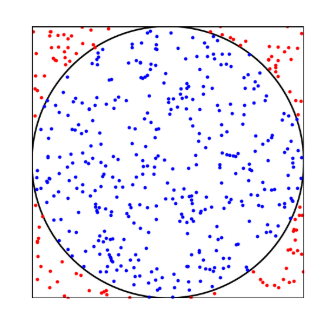

请你使用 `Python` 编写一个程序，利用上述方法估算 $\pi$ 的值，并输出结果，结果保留七位小数。 请设定 $N=100000$ ，随机数种子为 $102855$。

```python
import random, math

random.seed(102855)


def monte_carlo_estimate(random_func, times):
    return sum(1 if random_func() else 0 for _ in range(times)) / times


def mc_pi_func():
    return math.hypot(2 * random.random() - 1, 2 * random.random() - 1) <= 1


def mc_pi(N=100000):
    return 4 * monte_carlo_estimate(mc_pi_func, N)


print(f"π 的近似值为 {mc_pi():.7f}")
```

```
π 的近似值为 3.1485200
```

我又做了个动画演示

```python
import random, math
from ipycanvas import Canvas, hold_canvas
from IPython.display import display

random.seed(102855)


def draw(*args):
    in_cnt = sum(1 if math.hypot(x, y) <= 1 else 0 for x, y in args)
    with hold_canvas(canvas):
        canvas.clear()
        for x, y in args:
            canvas.fill_style = "red" if math.hypot(x, y) <= 1 else "blue"
            canvas.fill_arc(
                200 + 200 * x,
                200 + 200 * y,
                2,
                0,
                2 * math.pi,
            )
        canvas.fill_style = "black"
        canvas.font = "16px courier"
        canvas.fill_text(f"圈内点数： {in_cnt}", 410, 50)
        canvas.fill_text(f"总点数： {len(args)}", 410, 100)
        canvas.fill_text(f"π 的近似值：{4 * in_cnt / len(args):.7f}", 410, 150)


def gen_pos():
    return 2 * random.random() - 1, 2 * random.random() - 1


canvas = Canvas(size=(800, 400))
display(canvas)

canvas.stroke_rect(0, 0, 400, 400)
canvas.stroke_circle(200, 200, 200)

N = 3000  # 为了避免点数过多造成渲染困难，这里只取了 3000 个点
fps = 60
pts = [gen_pos() for _ in range(N)]
with hold_canvas():
    for i in range(0, N, 50):
        draw(*pts[: i + 1])
        canvas.sleep(1000 / fps)
    draw(*pts)
```

```
Canvas()
```